# Centrality and entropy measures of a functional network

```python
import numpy as np
import networkx as nx
import matplotlib.pyplot as plt

%matplotlib inline
```

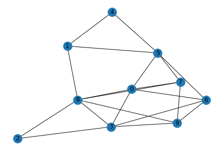

```python
# Creating a random graph
G = nx.erdos_renyi_graph(10, 0.5)
drw = nx.draw(G, with_labels=1)
```

## Betweenness Centrality

Betweenness centrality of a node $v$ is defined as fraction of sum of all-pair shortest paths that pass through $v$. \begin{equation*} c_B(v) =\sum_{s,t \in V} \frac{\sigma(s, t|v)}{\sigma(s, t)} \end{equation*} where $V$ is the set of nodes, $\sigma(s, t)$ is the number of shortest $(s, t)$-paths, and $\sigma(s, t|v)$ is the number of those paths passing through some node $v$ other than $s, t$. If $s = t$, $\sigma(s, t) = 1$, and if $v \in {s, t}, \sigma(s, t|v) = 0$

```python
bc = nx.betweenness_centrality(G)
```

```python
print(bc)
```

```
{0: 0.07129629629629629, 1: 0.08888888888888886, 2: 0.0, 3: 0.08287037037037036, 4: 0.0, 5: 0.18518518518518517, 6: 0.058796296296296284, 7: 0.0449074074074074, 8: 0.24583333333333332, 9: 0.027777777777777773}
```

```python
# calculating average betweenness centrality
avg_bc = sum(bc.values()) / len(bc)
print("Average betweenness centrality is", avg_bc)
```

```
Average betweenness centrality is 0.08055555555555556
```

## Closeness Centrality

For a connected graph, closeness centrality of a node $v$ is defined as inverse of sum of the shortest distance between $v$ and other $n-1$ nodes. \begin{equation*} C(u) = \frac{1}{\sum_{v=1}^{n-1} d(v, u)} \end{equation*} where $d(v, u)$ is the length of shortest path between node $v$ and $u$.

In other variation, above equation is scaled of by a factor of $n-1$, so as to represent average shortest distance of given node in the graph.

However, for disconnected graphs, there are various variants, like, taking sum of inverse of the shortest distance instead of inverse of the sum. This allows us to make $d(v, u) = \infty$, if $v$ and $u$ are not connected.

```python
cc = nx.algorithms.centrality.closeness_centrality(G)
```

```python
print(cc)
```

```
{0: 0.6923076923076923, 1: 0.6, 2: 0.5, 3: 0.6428571428571429, 4: 0.47368421052631576, 5: 0.6428571428571429, 6: 0.6428571428571429, 7: 0.6428571428571429, 8: 0.75, 9: 0.6}
```

```python
avg_cc = sum(cc.values()) / len(cc)
print('Average closeness centrality is', avg_cc)
```

```
Average closeness centrality is 0.6187420474262579
```

## Eigenvector Centrality

Eigenvector centrality is used as a ranking measure. It helps to find which nodes are important. Let $A$ be the adjacency matrix of graph $G$, $\lambda$ be the largest eigen-value of $A$ in absolute value. Let $x$ be the corresponding eigenvector. Then $EEC(i)$ for node $i = x_i$.

```python
eec = nx.algorithms.centrality.eigenvector_centrality(G)
print(eec)
```

```
{0: 0.4057846477590315, 1: 0.19387251239204553, 2: 0.18239315291979555, 3: 0.38073484498631077, 4: 0.11612731109485663, 5: 0.3148950911163204, 6: 0.32761335850689405, 7: 0.3362012740376332, 8: 0.4183590968601326, 9: 0.3339092243552182}
```

```python
avg_eec = sum(eec.values()) / len(eec)
print('Average eigenvector centrality is', avg_eec)
```

```
Average eigenvector centrality is 0.30098905140282384
```

## Degree Centrality

```python
dc = nx.algorithms.centrality.degree_centrality(G)
print(dc)
```

```
{0: 0.5555555555555556, 1: 0.3333333333333333, 2: 0.2222222222222222, 3: 0.5555555555555556, 4: 0.2222222222222222, 5: 0.5555555555555556, 6: 0.4444444444444444, 7: 0.4444444444444444, 8: 0.6666666666666666, 9: 0.4444444444444444}
```

```python
avg_dc = sum(dc.values()) / len(dc)
```

```python
print('Average degree centrality is', avg_dc)
```

```
Average degree centrality is 0.44444444444444453
```

```python
import seaborn as sbn
from numpy.linalg import eigvals
from scipy import stats
```

## Network Spectral Entropy

```python
n = 10
p = 0.5
nsamples = 10000
vs = np.array([0]*n)
for i in range(0,nsamples):
    G = nx.erdos_renyi_graph(n,p)
    A = nx.to_numpy_matrix(G)
    v = np.real(eigvals(A))
    vs = vs + v
vs = vs/nsamples
```

```python
vs = vs/(np.sqrt(n))
kde = stats.gaussian_kde(vs,bw_method='silverman')
x = np.linspace(vs.min(), vs.max(), 100)
rho = kde(x)
```

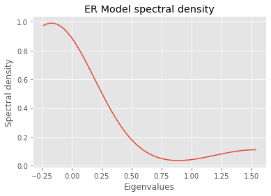

```python
plt.plot(x,rho)
plt.ylabel('Spectral density')
plt.xlabel('Eigenvalues')
plt.title('ER Model spectral density')
```